# Results - Wells by state and wildfire-year (primary analysis)

# 1 Description

# 2 Aggregated results for all states

## 2.1 Population exposed to wells in wildfire burn areas

### 2.1.4 Plot. Population exposed by year

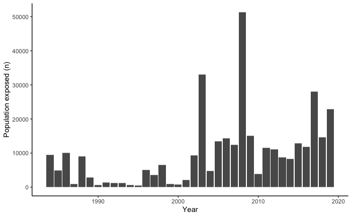

### 2.1.5 Table. Population exposed by year

| year | n |
| --- | --- |
| 1984 | 9525 |
| 1985 | 4852 |
| 1986 | 10057 |
| 1987 | 891 |
| 1988 | 8959 |
| 1989 | 2862 |
| 1990 | 561 |
| 1991 | 1410 |
| 1992 | 1195 |
| 1993 | 1247 |

[output cut: 26 more lines]

### 2.1.6 Plot. Population exposed by year with best fit line

Blue line is linear model; black line is cubic polynomial model

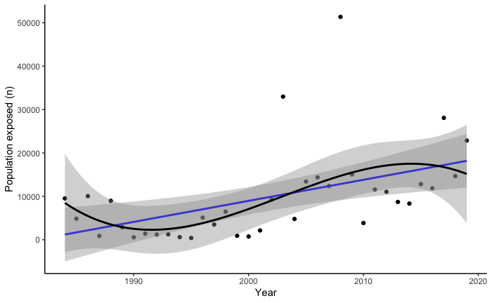

### 2.1.7 Model. Population exposed in burn area by state-year

```
Call:
glm(formula = pop_exposed_n ~ year + factor(state), data = pop_exposed_state_year)

Deviance Residuals:
   Min      1Q  Median      3Q     Max
 -7484    -468     -73     316   39840

Coefficients:
                  Estimate Std. Error t value Pr(>|t|)
(Intercept)     -74641.052  26068.534  -2.863  0.00439 **
year                37.309     13.022   2.865  0.00436 **
factor(state)CA   6985.826    689.788  10.127  < 2e-16 ***
factor(state)CO    -20.324    689.788  -0.029  0.97651
factor(state)KS    152.253    689.788   0.221  0.82541
factor(state)LA    -15.160    689.788  -0.022  0.98248
factor(state)MT    -29.200    689.788  -0.042  0.96625
factor(state)ND    -30.390    689.788  -0.044  0.96488
factor(state)NE    -32.012    689.788  -0.046  0.96301
factor(state)NM     51.199    689.788   0.074  0.94086
factor(state)OK   1649.648    689.788   2.392  0.01718 *
factor(state)TX    599.437    689.788   0.869  0.38530
factor(state)UT    -29.752    689.788  -0.043  0.96562
factor(state)WY     -8.012    689.788  -0.012  0.99074
---
Signif. codes:  0 ‘***’ 0.001 ‘**’ 0.01 ‘*’ 0.05 ‘.’ 0.1 ‘ ’ 1

(Dispersion parameter for gaussian family taken to be 8564546)

    Null deviance: 5589309023  on 467  degrees of freedom
Residual deviance: 3888303812  on 454  degrees of freedom
AIC: 8814.7

Number of Fisher Scoring iterations: 2
```

In a linear model adjusted for state, the exposed population increased significantly throughout the study period (p < 0.005).

# 3 Results stratified by state

## 3.1 Population exposed by state

### 3.1.1 Table. Population exposed by state

| state | pop_exposed_n_by_state |
| --- | --- |
| CA | 252644 |
| OK | 60542 |
| TX | 22734 |
| KS | 6635 |
| NM | 2998 |
| AR | 1154 |
| WY | 866 |
| LA | 609 |
| CO | 423 |
| MT | 103 |

[output cut: 3 more lines]

### 3.1.2 Plot. Population exposed by state

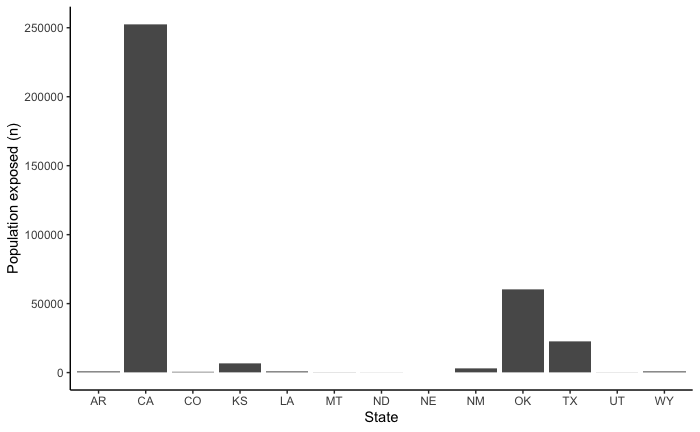

### 3.1.3 Table. Population exposed by state and year

| state | year | n |
| --- | --- | --- |
| AR | 1984 | 0 |
| AR | 1985 | 0 |
| AR | 1986 | 0 |
| AR | 1987 | 0 |
| AR | 1988 | 0 |
| AR | 1989 | 0 |
| AR | 1990 | 0 |
| AR | 1991 | 0 |
| AR | 1992 | 0 |
| AR | 1993 | 0 |

[output cut: 458 more lines]

### 3.1.4 Plot. Population exposed by state and year

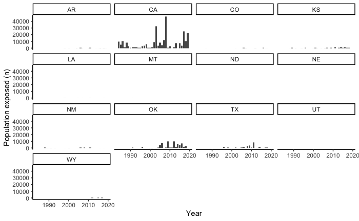

### 3.1.5 Plot. Population exposed by year with best fit line

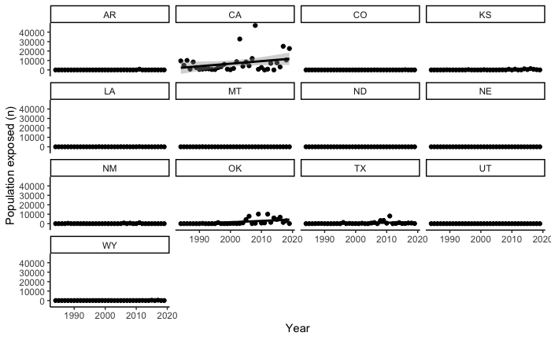

## 3.2 Investigating time trends by state

Fit OLS linear regression models to look at the association between n wells in burn areas and time (in years). Some notable heterogeneity among the three states with the most wells in burn areas.

### 3.2.1 Model. Population exposed by year and state (CA)

```
Call:
glm(formula = pop_exposed_n ~ year, data = subset(pop_exposed_state_year,
    state == "CA"))

Deviance Residuals:
   Min      1Q  Median      3Q     Max
-10403   -4964   -3145    1769   38323

Coefficients:
             Estimate Std. Error t value Pr(>|t|)
(Intercept) -534937.7   315700.5  -1.694   0.0993 .
year            270.8      157.7   1.717   0.0951 .
---
Signif. codes:  0 ‘***’ 0.001 ‘**’ 0.01 ‘*’ 0.05 ‘.’ 0.1 ‘ ’ 1

(Dispersion parameter for gaussian family taken to be 96653721)

    Null deviance: 3571070619  on 35  degrees of freedom
Residual deviance: 3286226514  on 34  degrees of freedom
AIC: 768.03

Number of Fisher Scoring iterations: 2
```

Weak association between advancing time and population exposed in California (p = 0.095)

### 3.2.2 Model. Population exposed by year and state (OK)

```
Call:
glm(formula = pop_exposed_n ~ year, data = subset(pop_exposed_state_year,
    state == "OK"))

Deviance Residuals:
    Min       1Q   Median       3Q      Max
-4145.6  -1410.8   -513.4    603.0   7391.0

Coefficients:
              Estimate Std. Error t value Pr(>|t|)
(Intercept) -288653.41   81677.72  -3.534  0.00120 **
year            145.06      40.81   3.555  0.00114 **
---
Signif. codes:  0 ‘***’ 0.001 ‘**’ 0.01 ‘*’ 0.05 ‘.’ 0.1 ‘ ’ 1

(Dispersion parameter for gaussian family taken to be 6469569)

    Null deviance: 301713695  on 35  degrees of freedom
Residual deviance: 219965345  on 34  degrees of freedom
AIC: 670.68

Number of Fisher Scoring iterations: 2
```

Increasing population exposure in Oklahoma (p < 0.01).

### 3.2.3 Model. Population exposed by year and state (TX)

```
Call:
glm(formula = pop_exposed_n ~ year, data = subset(pop_exposed_state_year,
    state == "TX"))

Deviance Residuals:
    Min       1Q   Median       3Q      Max
-1244.3   -650.4   -227.0     32.6   7036.3

Coefficients:
             Estimate Std. Error t value Pr(>|t|)
(Intercept) -84433.27   46764.89  -1.805   0.0799 .
year            42.50      23.36   1.819   0.0777 .
---
Signif. codes:  0 ‘***’ 0.001 ‘**’ 0.01 ‘*’ 0.05 ‘.’ 0.1 ‘ ’ 1

(Dispersion parameter for gaussian family taken to be 2120841)

    Null deviance: 79126034  on 35  degrees of freedom
Residual deviance: 72108584  on 34  degrees of freedom
AIC: 630.53

Number of Fisher Scoring iterations: 2
```

Weak association between advancing time and population exposed in Texas (p = 0.077)

### 3.2.4 Model. Population exposed by year and state (KS)

```
Call:
glm(formula = pop_exposed_n ~ year, data = subset(pop_exposed_state_year,
    state == "KS"))

Deviance Residuals:
    Min       1Q   Median       3Q      Max
-483.30  -205.94   -32.10    88.24   971.14

Coefficients:
             Estimate Std. Error t value Pr(>|t|)
(Intercept) -34443.95    9746.86  -3.534  0.00120 **
year            17.30       4.87   3.553  0.00114 **
---
Signif. codes:  0 ‘***’ 0.001 ‘**’ 0.01 ‘*’ 0.05 ‘.’ 0.1 ‘ ’ 1

(Dispersion parameter for gaussian family taken to be 92129.2)

    Null deviance: 4295290  on 35  degrees of freedom
Residual deviance: 3132393  on 34  degrees of freedom
AIC: 517.62

Number of Fisher Scoring iterations: 2
```

Positive time trend in KS (p = 0.001)

### 3.2.5 Model. Population exposed by year and state (NM)

```
Call:
glm(formula = pop_exposed_n ~ year, data = subset(pop_exposed_state_year,
    state == "NM"))

Deviance Residuals:
    Min       1Q   Median       3Q      Max
-119.98   -92.12   -70.67   -44.47   837.18

Coefficients:
             Estimate Std. Error t value Pr(>|t|)
(Intercept) -4116.025   6829.197  -0.603    0.551
year            2.098      3.412   0.615    0.543

(Dispersion parameter for gaussian family taken to be 45228)

    Null deviance: 1554853  on 35  degrees of freedom
Residual deviance: 1537752  on 34  degrees of freedom
AIC: 492.01

Number of Fisher Scoring iterations: 2
```

No time trend in NM

### 3.2.6 Model. Population exposed by year and state (AR)

```
Call:
glm(formula = pop_exposed_n ~ year, data = subset(pop_exposed_state_year,
    state == "AR"))

Deviance Residuals:
   Min      1Q  Median      3Q     Max
-62.95  -35.00  -16.21    0.47  696.41

Coefficients:
             Estimate Std. Error t value Pr(>|t|)
(Intercept) -5257.331   3978.442  -1.321    0.195
year            2.643      1.988   1.330    0.193

(Dispersion parameter for gaussian family taken to be 15349.5)

    Null deviance: 549016  on 35  degrees of freedom
Residual deviance: 521883  on 34  degrees of freedom
AIC: 453.1

Number of Fisher Scoring iterations: 2
```

No time trend in AR